# InstaCart Predictive Analysis: Predicting Orders

April Leclair, Daniel Ochoa, Hoang Anh Thai Vu, Qiuhan Sun

This file is used to predict what products a user will order next

# Reading In The Data

```r
orders <- read_csv("../Source/orders_sample40.csv")
order_products <- read_csv("../Source/order_products_sample40.csv")
products <- read_csv("../Source/products.csv")
```

# Preparing the Data

Cleaning the data by changing variable types (maybe add more to this and move to seperate file in /DataPrep)

```r
orders$eval_set <- as.factor(orders$eval_set)
products$product_name <- as.factor(products$product_name)
```

We want to build our model only on the `prior` dataset.

```r
orders_prior <-
  orders %>%
  filter(eval_set == "prior")

order_products_prior <-
  order_products %>%
  inner_join(orders_prior, by="order_id")
```

We are going to want the results of the `train` dataset for cross-validation later.

```r
orders_train <-
  orders %>%
  filter(eval_set == "train")

order_products_train <-
  order_products %>%
  inner_join(orders_train, by="order_id")
```

# Feature Engineering

We are going to want data specific to each user, each product, and each user-product interaction. The features that come in the vanilla datasets aren’t quite telling enought so we are going to build some of our own.

(Maybe move feature engineering to seperate script in /DataPrep)

## Feature Engineering: Products

Adding product specific features

```r
prods <- order_products_prior %>%
  arrange(user_id, order_number, product_id) %>%
  group_by(user_id, product_id) %>%
  mutate(product.numTimes = row_number()) %>% #  Number of times this product has appeared so far for this user
  ungroup() %>%
  group_by(product_id) %>%
  summarise(product.orders = n(),
            product.reorders = sum(reordered),
            product.firstOrders = sum(product.numTimes == 1), # number of users that have ordered this product
            product.secondOrders = sum(product.numTimes == 2)) %>% # number of users that ordered this product more than once
  mutate(product.reorderProbability = product.secondOrders / product.firstOrders) %>%
  mutate(product.avgTimesOrdered = 1 + product.reorders / product.firstOrders) %>%
  mutate(product.reorderRatio = product.reorders / product.orders) %>%
  select(-product.reorders, -product.firstOrders, -product.secondOrders)
```

## Feature Engineering: Users

Adding user specific features

```r
users <- orders_prior %>%
  group_by(user_id) %>%
  summarise(user.numOrders = max(order_number),
            user.useInterval = sum(days_since_prior_order, na.rm=TRUE),
            user.avgDaysSincePriorOrder = mean(days_since_prior_order, na.rm=TRUE))
```

Some user specific features require data on the number of products they order

```r
user_products <- order_products_prior %>%
  group_by(user_id) %>%
  summarise(user.totalProducts = n(),
            user.reorderRatio = sum(reordered == 1) / sum(order_number > 1))

users <- users %>%
  inner_join(user_products, by="user_id") %>%
  mutate(user.avgOrderSize = user.totalProducts / user.numOrders)

rm(user_products)
```

Finally let’s add the `test` and `train` orders for each user to the users table to be used later for predictions (days_since_prior_order) and in seperating of cross-validation and test prediction sets.

```r
users_finalOrder <- orders %>%
  filter(eval_set != "prior") %>%
  select(user_id, order_id, days_since_prior_order, eval_set)

users <- users %>%
  inner_join(users_finalOrder, by="user_id")
```

## Feature Engineering: User-Product

```r
user_products <- order_products_prior %>%
  group_by(user_id, product_id) %>%
  summarise(
    user_product.orders = n(),
    user_product.firstOrder = min(order_number),
    user_product.lastOrder = max(order_number),
    user_product.avgCartPosition = mean(add_to_cart_order))
```

# Data: Build Main Data Set

```r
data <- user_products %>%
  inner_join(prods, by = "product_id") %>%
  inner_join(users, by = "user_id")
```

We join with train dataset reorders to train model in which products are reordered. (I think this means that we are currently only considering possible products that a user can order from the products they have already ordered.)

```r
data <- data %>%
  left_join(order_products_train %>% select(user_id, product_id, reordered),
            by = c("user_id", "product_id"))
```

# Data: Test and Train

```r
train <- data %>%
  ungroup() %>%
  filter(eval_set == "train") %>%
  select(-eval_set, -user_id)

train$reordered[is.na(train$reordered)] <- 0
```

```r
test <- data %>%
  ungroup() %>%
  filter(eval_set == "test") %>%
  select(-eval_set, -user_id, -reordered)
```

```r
set.seed(567)
sampleTrain <- train %>%
   sample_frac(0.1)

crossVal <- train %>%
  filter(!order_id %in% sampleTrain$order_id)
```

# Predictions

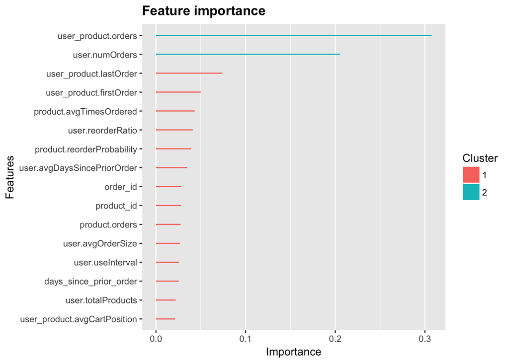

```r
trainingMatrix <- xgb.DMatrix(as.matrix(sampleTrain %>% select(-reordered)), label = sampleTrain$reordered)
model <- xgboost(data = trainingMatrix, objective="binary:logistic",nrounds = 80, verbose=0)
importance <- xgb.importance(colnames(trainingMatrix), model = model)
xgb.ggplot.importance(importance)
```

We can see from this which features are the most important. It is no suprie that user_product.orders is very important but we were surpised to find that user.numOrders is very important too. We will investigate this in the future.

```r
testMatrix <- xgb.DMatrix(as.matrix(test))
test$reordered <- predict(model, testMatrix)
test$reordered <- (test$reordered > 0.95) * 1 # 0.95 is random threshold I came up with, experiment with it
```

```r
crossValMatrix <- xgb.DMatrix(as.matrix(crossVal))
crossVal$reordered <- predict(model, crossValMatrix)
crossVal$reordered <- (crossVal$reordered > 0.20) * 1 # 0.20 is random threshold I came up with, experiment with it
```

Let picture the accuracy of predictions

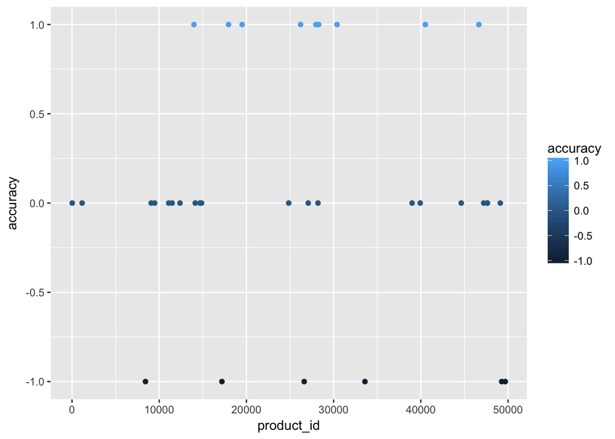

```r
crossVal_ex <- crossVal %>%
  filter(order_id == 1725556) %>%
  mutate(predictedToOrder = reordered) %>%
  select(product_id, predictedToOrder)

order_products_ex <- order_products %>%
  filter(order_id == 1725556) %>%
  mutate(actuallyOrder = 1) %>%
  select(product_id, actuallyOrder)

prediction_table <- order_products_ex %>%
  full_join(crossVal_ex, by="product_id")

prediction_table <- replace(prediction_table,is.na(prediction_table),0)
prediction_table <- prediction_table %>%
  mutate(accuracy = actuallyOrder - predictedToOrder) %>%
  select(product_id, accuracy)

ggplot(data=prediction_table, aes(x=product_id, y=accuracy)) + geom_point(aes(color=accuracy))
```

We can see from this graphic that the model was able to correctly predict some of the products that the order would contain. However, the model also predicts some products that the user did not order, in addition the model fails to predict a number of products that the user did in fact order.